# HW 2

Songru Wang

10/5/2021

## R Markdown

Data Wrangling–> you can merge these datasets using the location variable. Once combined, you will need to do the following: 1. In the case of missing values, impute data using the average within the variables “male” and “hispanic.”

```r
library(readr)
chs_individual <- read_csv("~/Desktop/USC/Master/Fall Semester/Introduction to Health Data Science/HW 2/chs_individual.csv")
chs_regional_2 <- read_csv("~/Desktop/USC/Master/Fall Semester/Introduction to Health Data Science/HW 2/chs_regional-2.csv")
chs<-merge(chs_individual,chs_regional_2,by="townname")

chs_c<-chs
chs_mh<-
  chs%>%
  filter(male==1 & hispanic ==1)
ag<-as.numeric(chs$agepft)
hei<-as.numeric(chs$height)
wei<-as.numeric(chs$weight)
BmI<-as.numeric(chs$bmi)

chs_c$agepft<-fcoalesce(ag,mean(chs_mh$agepft,na.rm=TRUE))
chs_c$height<-fcoalesce(hei,mean(chs_mh$height,na.rm=TRUE))
chs_c$weight<-fcoalesce(wei,mean(chs_mh$weight,na.rm=TRUE))
chs_c$bmi<-fcoalesce(BmI,mean(chs_mh$bmi,na.rm=TRUE))


for (i in 21:ncol(chs_c)) {
  chs_c[,i]<-fcoalesce(chs_c[,i],mean(chs_mh[,i],na.rm=TRUE))
}
```

2.Create a new categorical variable named “obesity_level” using the BMI measurement (underweight BMI<14; normal BMI 14-22; overweight BMI 22-24; obese BMI>24). To make sure the variable is rightly coded, create a summary table that contains the minimum BMI, maximum BMI, and the total number of observations per category.

```r
chs_c<-
  chs_c%>%
  mutate(obesity_level= case_when(
    bmi<=14 ~ "underweight",
    bmi>14 & bmi<=22 ~ "normal",
    bmi>22 & bmi<=24 ~ "overweight",
    bmi>24 ~ "obse"
  ))

summary(chs_c$bmi)
```

```
##    Min. 1st Qu.  Median    Mean 3rd Qu.    Max.
##   11.30   15.96   17.81   18.57   19.99   41.27
```

```r
chs_c%>%
  group_by(obesity_level)%>%
  summarise(count=n())
```

```
## # A tibble: 4 × 2
##   obesity_level count
##   <chr>         <int>
## 1 normal          975
## 2 obse            103
## 3 overweight       87
## 4 underweight      35
```

3.Create another categorical variable named “smoke_gas_exposure” that summarizes “Second Hand Smoke” and “Gas Stove.” The variable should have four categories in total.

```r
chs_c<-
  chs_c%>%
  mutate(smoke_gas_exposure=case_when(
    smoke==0 & gasstove==0 ~ "No S & No gas",
    smoke==1 & gasstove==0 ~ "S & No gas",
    smoke==0 & gasstove==1 ~ "No S & gas",
    smoke==1 & gasstove==1 ~ "S & gas"
  ))
```

4.Create four summary tables showing the average (or proportion, if binary) and sd of “Forced expiratory volume in 1 second (ml)” and asthma indicator by town, sex, obesity level, and “smoke_gas_exposure.”

```r
#FEV
chs_c%>%
  group_by(townname)%>%
  summarize(mean(fev/60),sd(fev/60))
```

```
## # A tibble: 12 × 3
##    townname      `mean(fev/60)` `sd(fev/60)`
##    <chr>                  <dbl>        <dbl>
##  1 Alpine                  34.8         4.84
##  2 Atascadero              34.7         5.39
##  3 Lake Elsinore           34.1         5.06
##  4 Lake Gregory            34.9         5.31
##  5 Lancaster               33.6         5.31
##  6 Lompoc                  34.1         5.85
##  7 Long Beach              33.2         5.34
##  8 Mira Loma               33.2         5.44
##  9 Riverside               33.3         4.65
## 10 San Dimas               33.8         5.32
## 11 Santa Maria             33.9         5.21
## 12 Upland                  33.9         5.72
```

```r
#asthma

chs_c%>%
  filter(asthma==1)%>%
  group_by(townname)%>%
  summarize(n())
```

```
## # A tibble: 12 × 2
##    townname      `n()`
##    <chr>         <int>
##  1 Alpine           11
##  2 Atascadero       25
##  3 Lake Elsinore    12
##  4 Lake Gregory     15
##  5 Lancaster        16
##  6 Lompoc           11
##  7 Long Beach       13
##  8 Mira Loma        15
##  9 Riverside        11
## 10 San Dimas        17
## 11 Santa Maria      13
## 12 Upland           12
```

```r
chs_c%>%
  filter(asthma==1)%>%
  group_by(male)%>%
  summarize(n())
```

```
## # A tibble: 2 × 2
##    male `n()`
##   <dbl> <int>
## 1     0    72
## 2     1    99
```

```r
chs_c%>%
  filter(asthma==1)%>%
  group_by(obesity_level)%>%
  summarize(n())
```

```
## # A tibble: 4 × 2
##   obesity_level `n()`
##   <chr>         <int>
## 1 normal          133
## 2 obse             21
## 3 overweight       14
## 4 underweight       3
```

```r
chs_c%>%
  filter(asthma==1)%>%
  group_by(smoke_gas_exposure)%>%
  summarize(n())
```

```
## # A tibble: 5 × 2
##   smoke_gas_exposure `n()`
##   <chr>              <int>
## 1 No S & gas           108
## 2 No S & No gas         31
## 3 S & gas               19
## 4 S & No gas             6
## 5 <NA>                   7
```

Looking at the Data (EDA) The primary questions of interest are: 1. What is the association between BMI and FEV (forced expiratory volume)? 2. What is the association between smoke and gas exposure and FEV? 3. What is the association between PM2.5 exposure and FEV?

1.Facet plot showing scatterplots with regression lines of BMI vs FEV by “townname”.

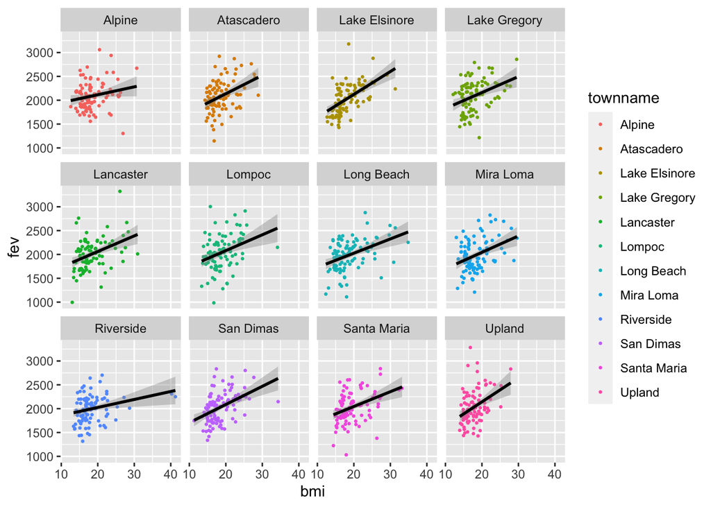

```r
library(ggplot2)
chs_c%>%
  ggplot(aes(x=bmi,y=fev,color=townname))+
  geom_point(size=0.5)+
  geom_smooth(method="lm",color="black")+
  facet_wrap(~townname)
```

```r
## According the overall graphs, I found there are positive relationships
```

2.Stacked histograms of FEV by BMI category and FEV by smoke/gas exposure. Use different color schemes than the ggplot default.

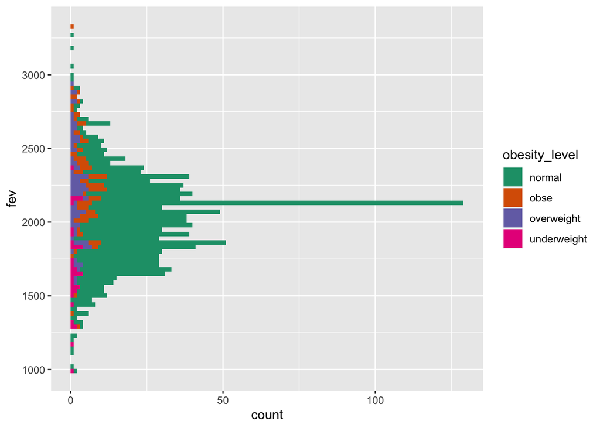

```r
library(ggplot2)
library(RColorBrewer)
chs_c%>%
  ggplot(aes(x=fev,fill=obesity_level))+
  geom_histogram(binwidth=30)+
  scale_fill_brewer(palette="Dark2")+
  coord_flip()
```

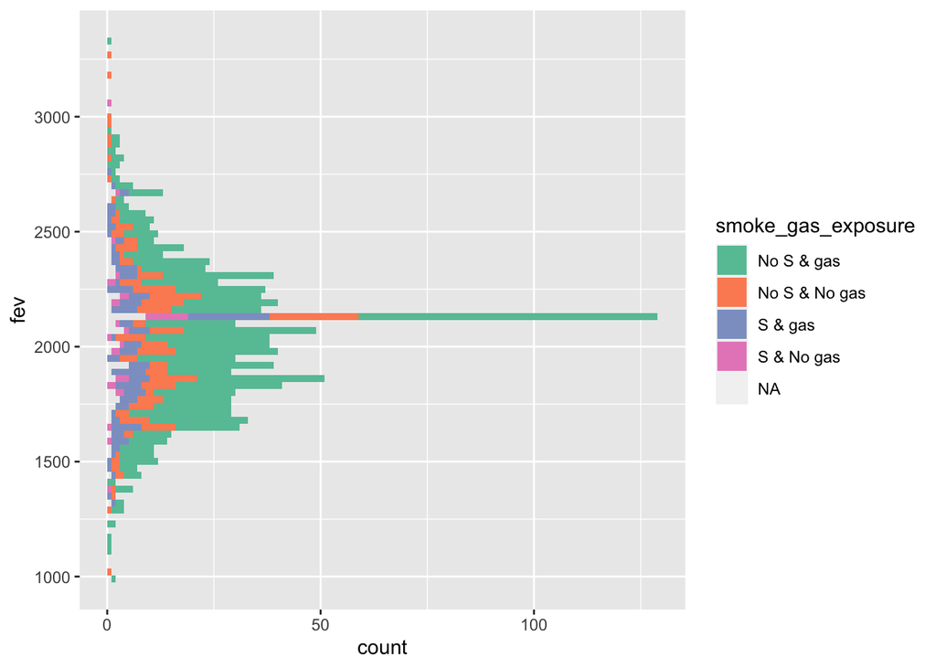

```r
chs_c%>%
  ggplot(aes(x=fev,fill=smoke_gas_exposure))+
  geom_histogram(binwidth = 30)+
  scale_fill_brewer(palette="Set2")+
  coord_flip()
```

3.Barchart of BMI by smoke/gas exposure.

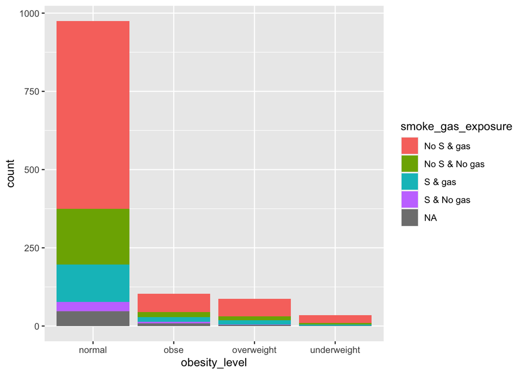

```r
ggplot(chs_c,
       aes(x=obesity_level,fill=smoke_gas_exposure))+
  geom_bar(position='stack')
```

4.Statistical summary graphs of FEV by BMI and FEV by smoke/gas exposure category.

```
## No summary function supplied, defaulting to `mean_se()`
```

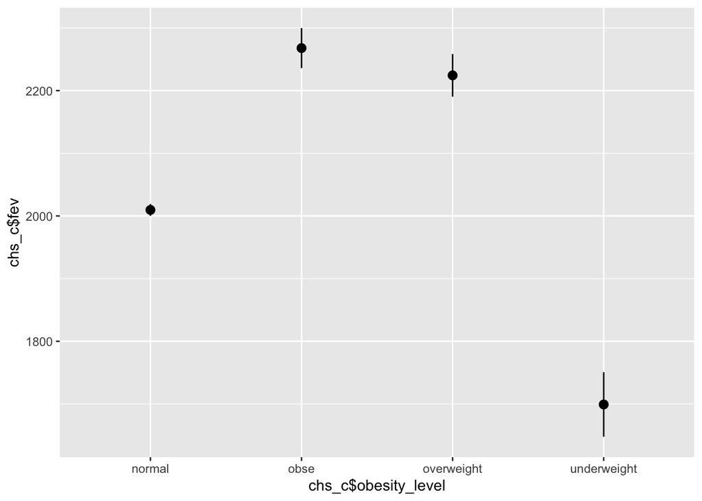

```r
ggplot(mapping = aes(x=chs_c$obesity_level,y=chs_c$fev))+
  stat_summary()+
  stat_summary(
    mapping = aes(x=chs_c$obesity_level,y=chs_c$fev),
    fun.min = min,
    fun.max = max,
    fun="mean_sd1")
```

```
## No summary function supplied, defaulting to `mean_se()`
```

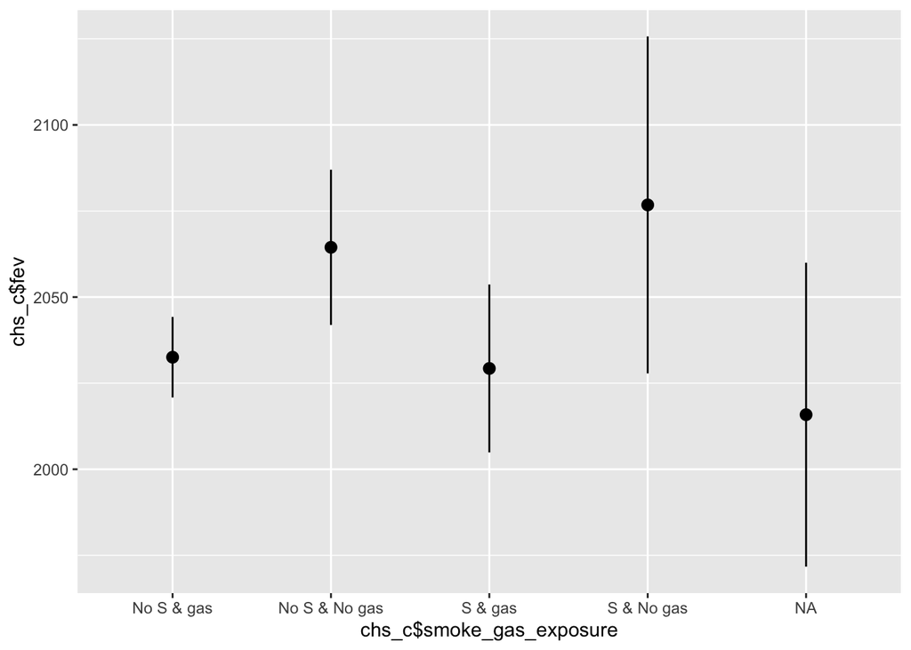

```r
ggplot(mapping = aes(x=chs_c$smoke_gas_exposure,y=chs_c$fev))+
  stat_summary()+
  stat_summary(
    mapping = aes(x=chs_c$smoke_gas_exposure,y=chs_c$fev),
    fun.min = min,
    fun.max = max,
    fun="mean_sd1")
```

5.A leaflet map showing the concentrations of PM2.5 mass in each of the CHS communities.

```r
library(leaflet)

commu.pal <- colorNumeric(c('darkgreen','goldenrod','brown'), domain=chs_c$pm25_mass)
leaflet(chs_c)%>%
  addProviderTiles('CartoDB.Positron')%>%
  addCircles(
    lat = ~lat,lng = ~lon,
    label = ~paste0(round(pm25_mass,2)),color = ~commu.pal(pm25_mass),
    opacity = 1, fillOpacity = 1, radius = 500
  )%>%
  addLegend('bottomleft',pal = commu.pal,values = chs_c$pm25_mass,title = 'PM2.5 Concentration',opacity = 1)
```

[interactive chart not shown]

6.Choose a visualization to examine whether PM2.5 mass is associated with FEV.

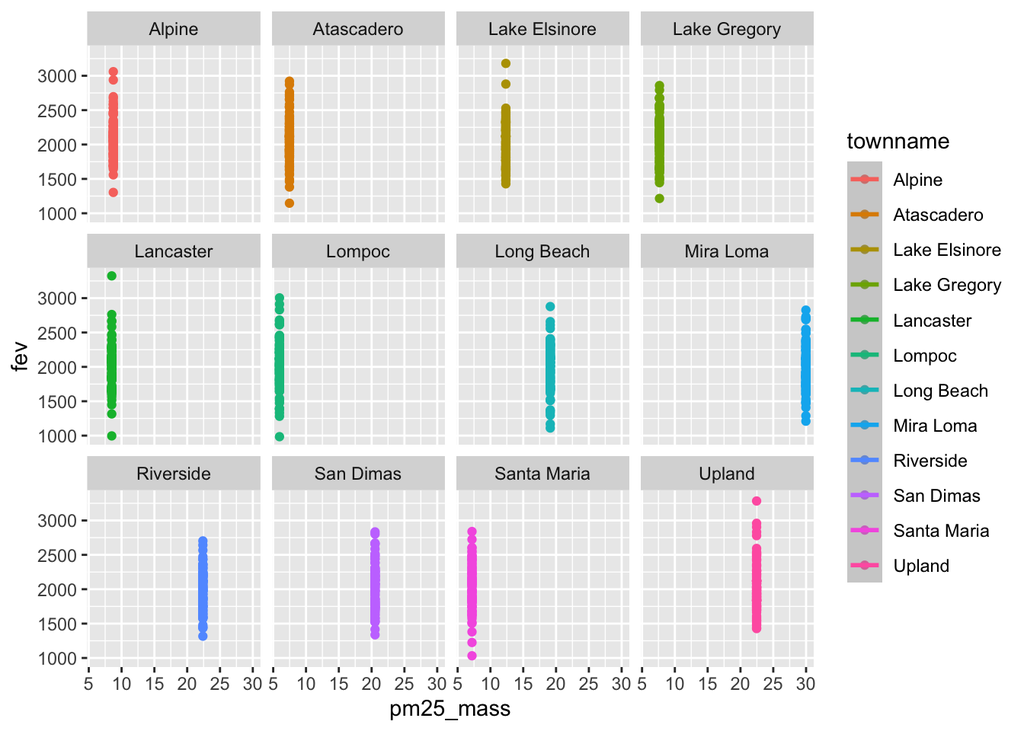

```r
chs_c%>%
  ggplot(aes(x=pm25_mass,y=fev,color=townname))+
  geom_point()+
  geom_smooth(method = "lm")+
  facet_wrap(~townname)
```